# Data Exploration : Attrition Analytics

Ameya Ghasias, Dhijith CD, Urvi Kalia

23 June 2016

## Introduction

The purpose of this documentation is to showcase the findings of the exploratory data analysis on attrition dataset, obtained from IBM watson analytics website .

To brief about the dataset , It contains details about past employees of a company (details not known).It includes demographic details, work related details, various ratings and whether the employee has left the company or not.

Since the source of the data is not known, here are some asumptions on which further analysis will be based.

- The given data is a representive sample.It is assumed that the simple random sampling technique is used to draw/collect data and hence the inferences can be generaized.
- It is assumed that the data collection was as per required standards with minimal or no data collection issues.

## Setup

The initial setup includes loading the required packages and the data.

### Load packages

```r
library(ggplot2)
library(dplyr)
library(grid)
library(gridExtra)
library(gmodels)
library(corrplot)
```

### Load Data

```r
employeeData <-read.csv("HR-Employee-Attrition.csv",header = TRUE)
sum(is.na(employeeData))
```

```
## [1] 0
```

```r
dim(employeeData)
```

```
## [1] 1470   35
```

The dataset contain no missing values.

### PreProcessing

Mentioned below are some of the preprocessing done :

1. Few variables have numeric ratings.These are transformed to a readable format as factors.Attributes which are transformed as factors are :
   - *Education*
   - *Environment Satisfaction*
   - *Job Involvement*
   - *Job Satisfaction*
   - *Performance rating*
   - *Relationship satisfaction*
   - *Work life balance*
2. Atrributes named *JobLevel* and *StockOptionLevel* are also changed to categorical , as they represent levels.
3. Attributes named *EmployeeCount* , *Over18* , *StandardHours* are ignored, as they are constants or should be said uniformly distributed across.
4. *EmployeeNumber* to be considered as row names.
5. *Attrition* is the response variable.

After all the above preprocessing we are left with 31 variables , including the response variable.17 of them being categorical variables and 14 numeric.

## Categorical variables

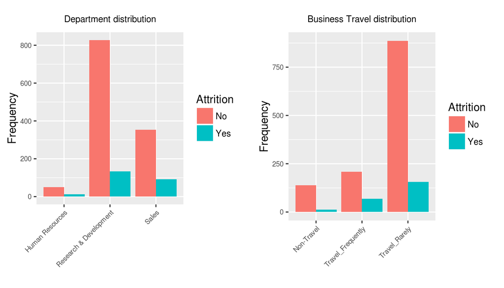

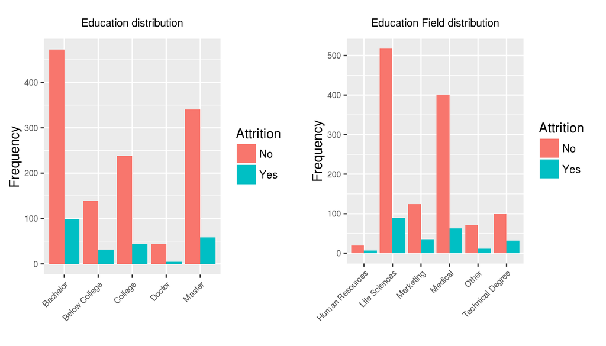

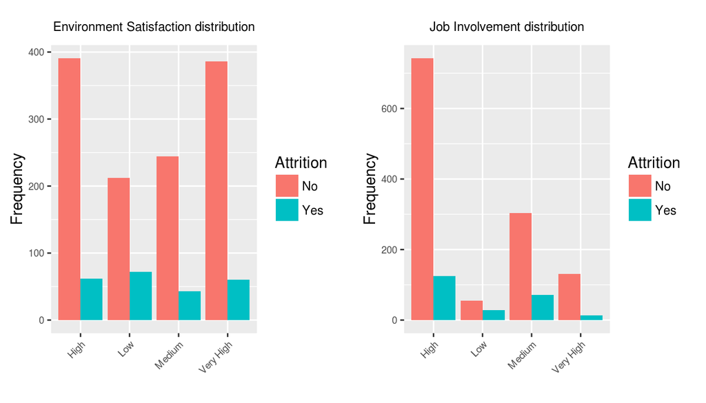

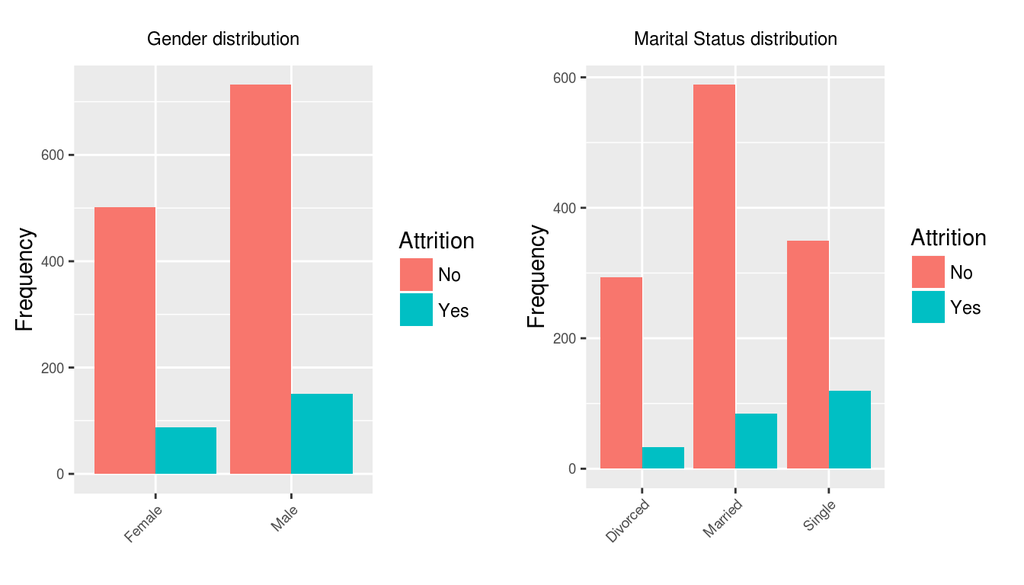

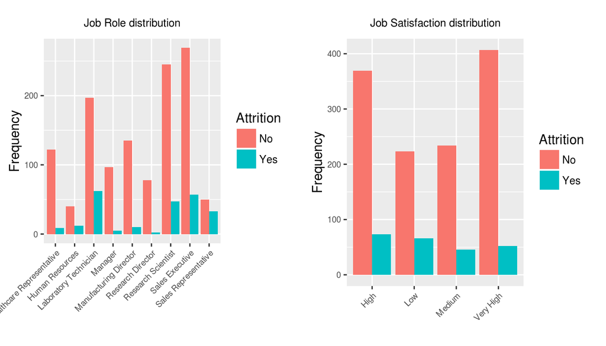

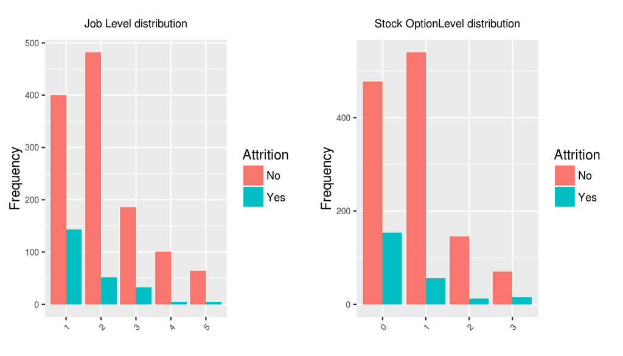

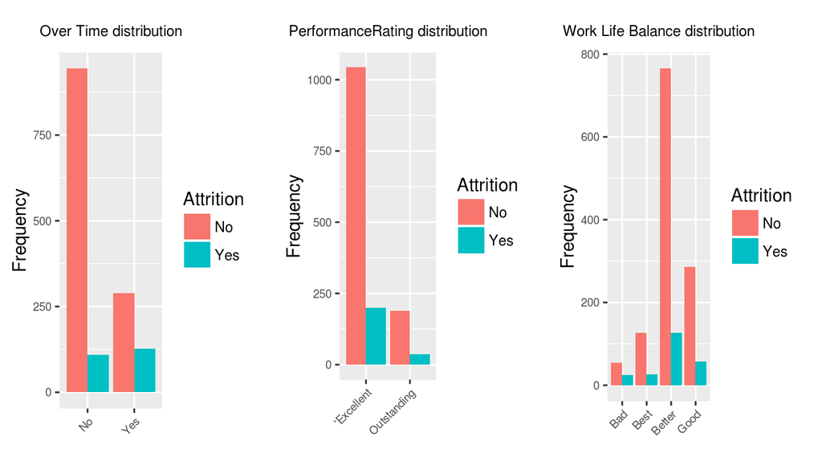

Using Chi-square test of independence ,independence of categorical variable with *Attrition* can be evaluated.

| Variable | P- value |
| --- | --- |
| Department | 0.0045256 |
| Business Travel | 5.608614510^{-6} |
| Education | 0.5455253 |
| Education Field | 0.006774 |
| Environment Satisfaction | 5.123468910^{-5} |
| Job involvement | 2.863180610^{-6} |
| Gender | 0.2905724 |
| Marital status | 9.455511110^{-11} |
| Job role | 2.752481610^{-15} |
| Job Satisfaction | 5.563004510^{-4} |
| Job level | 6.634684710^{-15} |
| Stock Options level | 4.379390310^{-13} |
| Overtime | 8.158423710^{-21} |
| Performance Rating | 0.9900745 |
| Work life balance | 9.725698810^{-4} |

From the above table, we can infer *Attrition* and *Business Travel* , *Environment Satisfaction*, *Job involvement* , *Marital status* , *Job role* , *Job Satisfaction*, *Job level* , *Stock Options level*, *Overtime* and *Work life balance* are not independent.

```r
CrossTable(employeeData$OverTime,employeeData$Attrition)
```

```
##
##
##    Cell Contents
## |-------------------------|
## |                       N |
## | Chi-square contribution |
## |           N / Row Total |
## |           N / Col Total |
## |         N / Table Total |
## |-------------------------|
##
##
## Total Observations in Table:  1470
##
##
##                       | employeeData$Attrition
## employeeData$OverTime |        No |       Yes | Row Total |
## ----------------------|-----------|-----------|-----------|
##                    No |       944 |       110 |      1054 |
##                       |     4.063 |    21.136 |           |
##                       |     0.896 |     0.104 |     0.717 |
##                       |     0.766 |     0.464 |           |
##                       |     0.642 |     0.075 |           |
## ----------------------|-----------|-----------|-----------|
##                   Yes |       289 |       127 |       416 |
##                       |    10.293 |    53.552 |           |
##                       |     0.695 |     0.305 |     0.283 |
##                       |     0.234 |     0.536 |           |
##                       |     0.197 |     0.086 |           |
## ----------------------|-----------|-----------|-----------|
##          Column Total |      1233 |       237 |      1470 |
##                       |     0.839 |     0.161 |           |
## ----------------------|-----------|-----------|-----------|
##
##
```

Attrition rate is higher amoung the employees working over time.Working over time , seams to be a vital indicator.

## Numeric variables

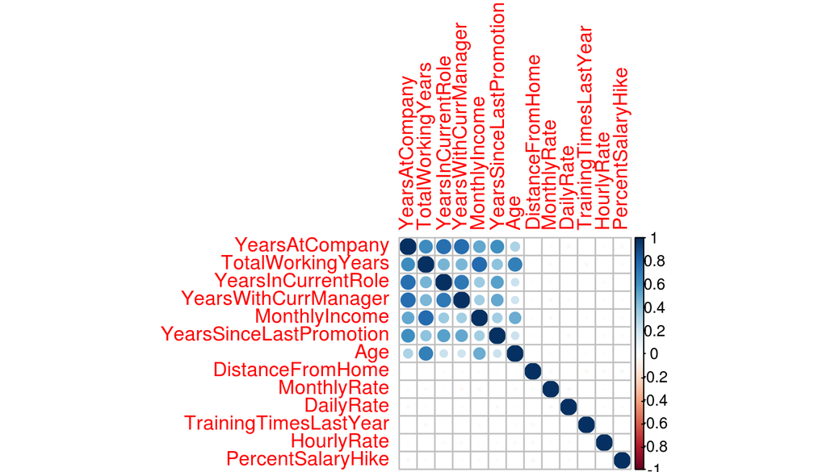

Correlation plot clearly depicts, high correlation among the following :

- Years with Current Manager, Years at current company and years in current role
- Age and Total working years
- Monthly Income and Total working years
- Years at company and total working years

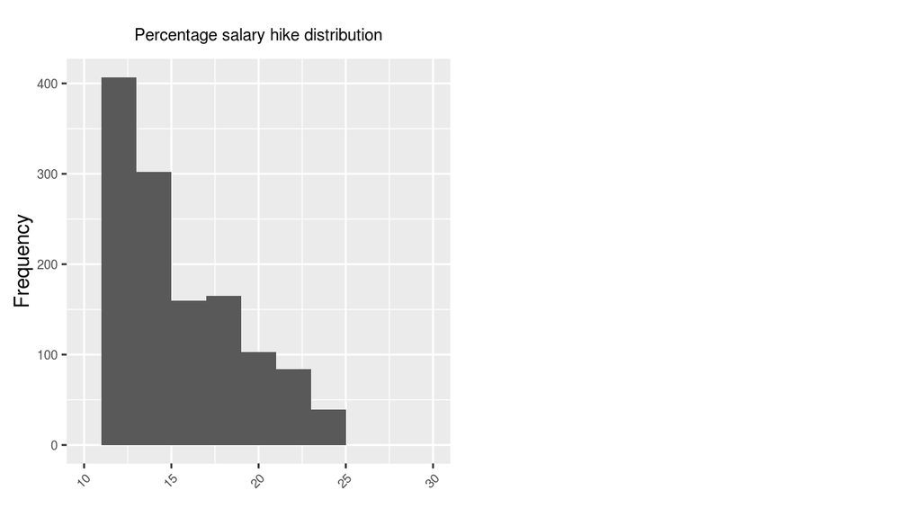

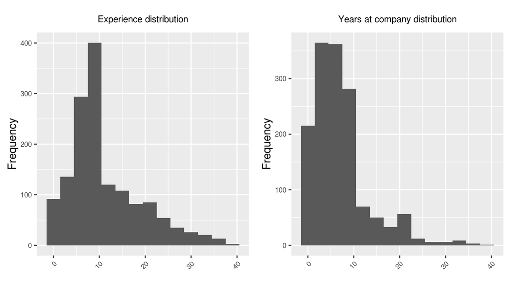

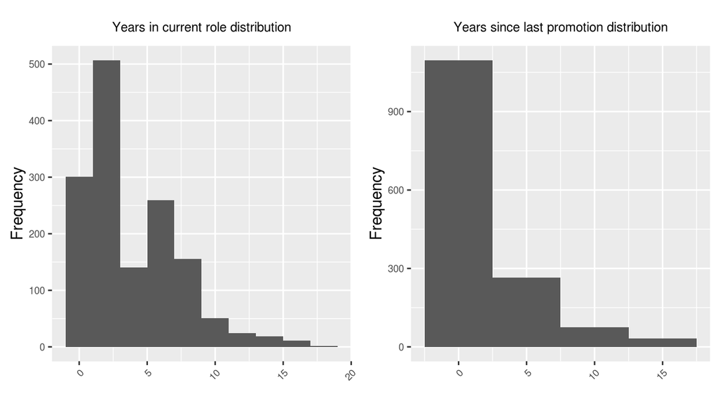

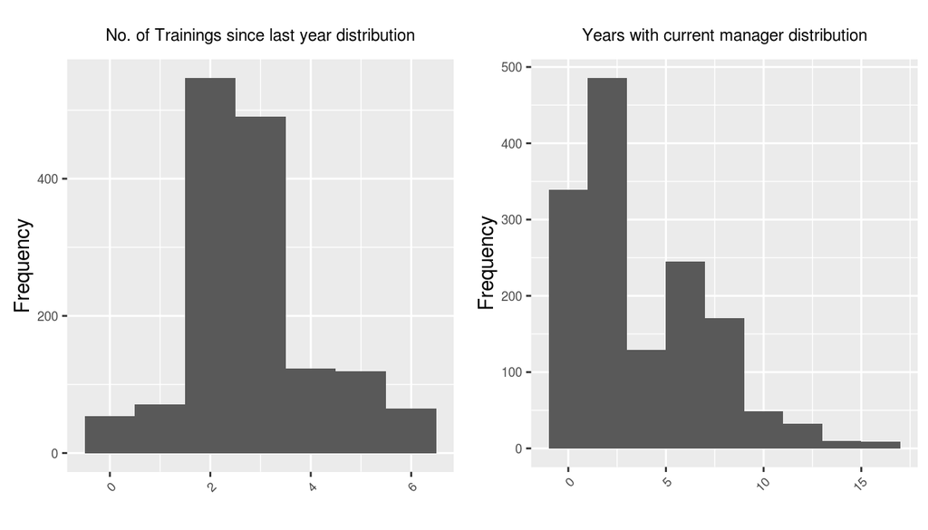

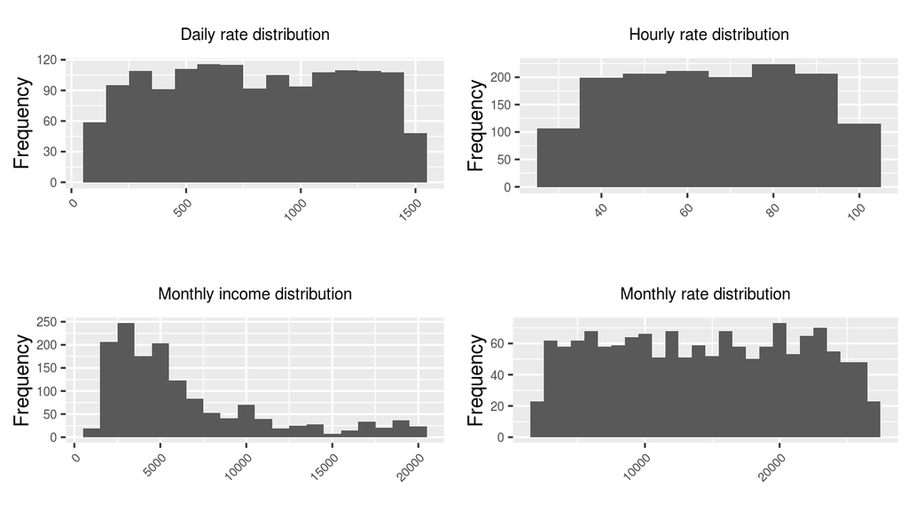

Distribution of daily rate,hourly rate and monthly rate appears to be uniform.Technically they should have a similar distribution as of monthly income.But there appears to be quite a lot of difference. Since details about the data are not known, these variables will not be considered while modeling.

## Conclusion

Finally we are left with 16 categorical variables and 11 numeric varaibles.